# Main and Supplemental Figures and Tables for Drought MS -

Teresa Bohner

2/25/2020

## Questions

1. How do species differ in their drought response to variable intensity and their recovery patterns?
2. If species differ, do they also vary regionally? For which species?
3. Are drought response and recovery mediated by competition and tree size and is this a species specific phenomenon or does it also vary regionally?

## Methods

I collected tree ring data from 4 regions across California and performed analyses on detrended growth during drought years where water availability (SPEI) was in the bottom 10th percentile. All tree ring series were spline detrended.

#### Key responses

$$Growth Reduction = \frac{\overline{RWI}_{non-drought} - RWI_{drought}}{\overline{RWI}_{non-drought}}$$
$$Recovery = RWI_{actual} - RWI_{pred}$$

Where $RWI_{pred}$ is the predicted growth for a tree given the post-drought year conditions based on hierarchical Bayesian models of all growth years.

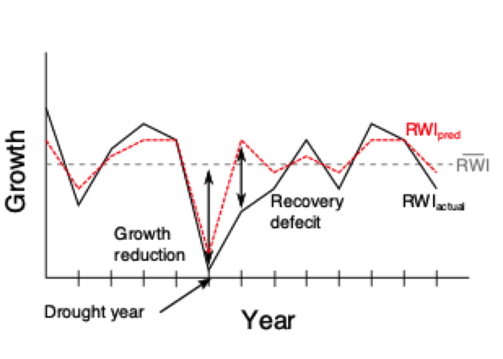

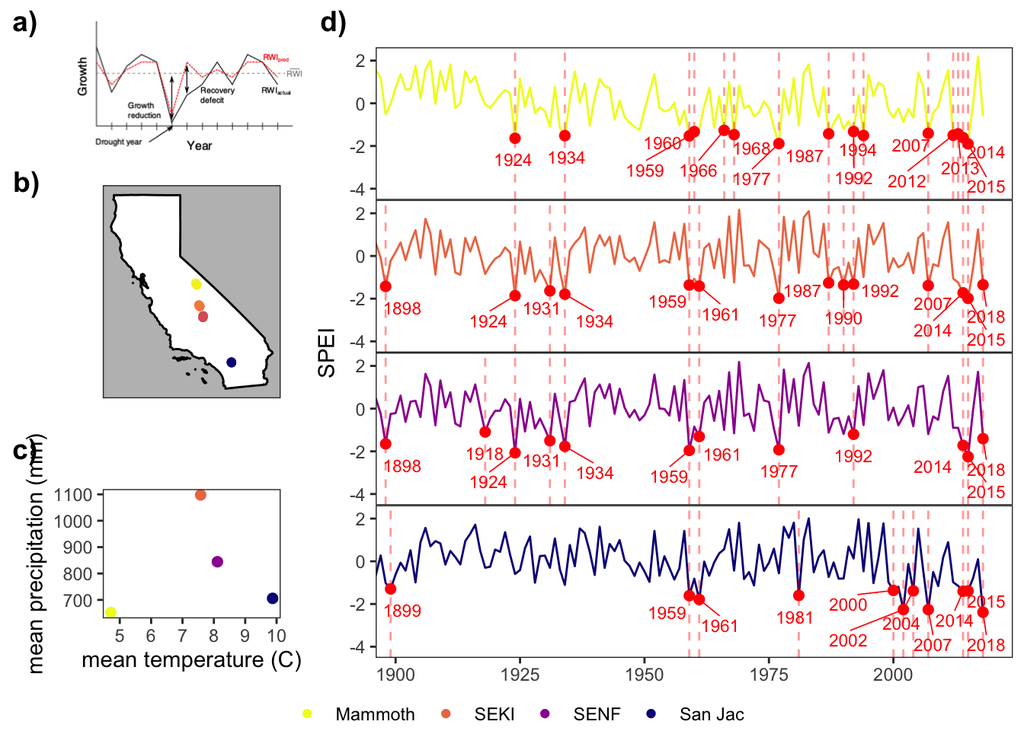

[figure not shown]

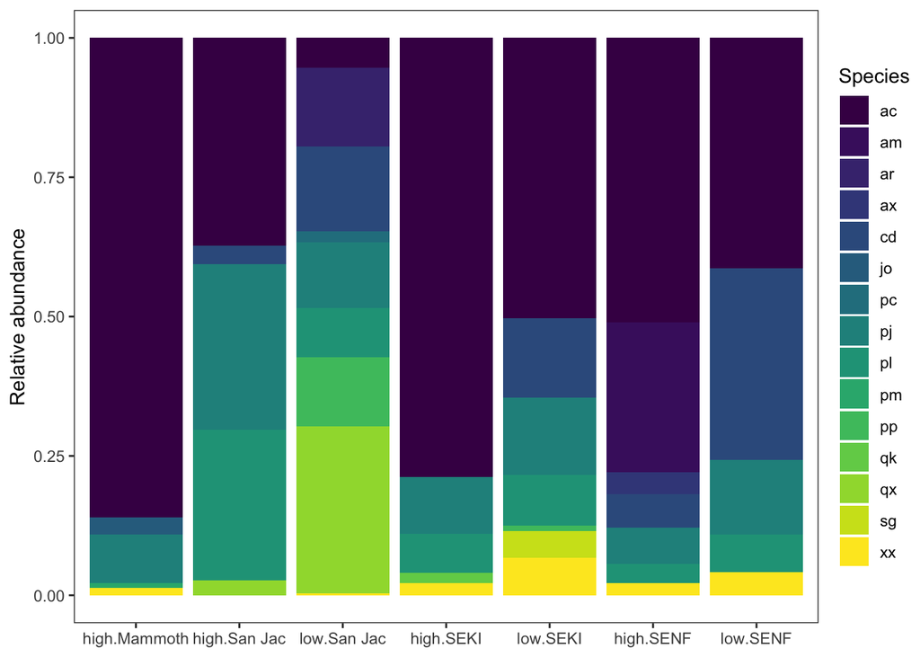

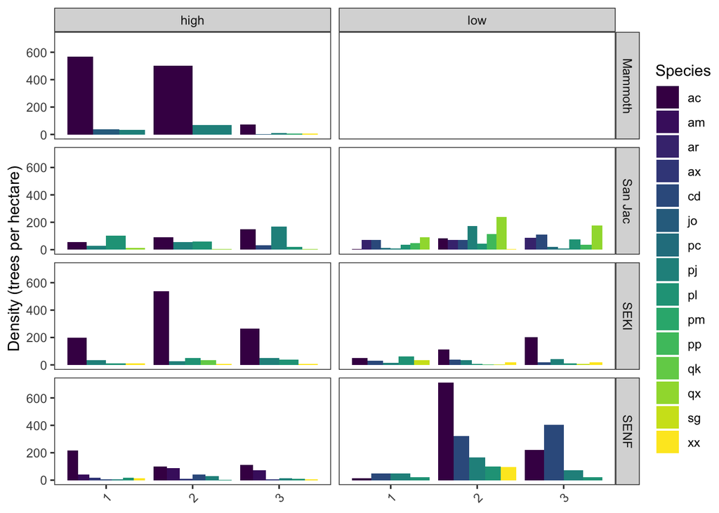

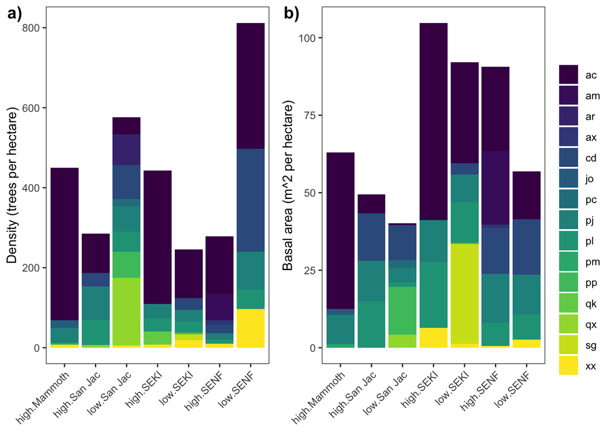

## Full model approach to Q3

This approach differs in that here we explore the results of the full expression of the model to answer the above questions i.e. the most complex justifiable model. Each species is modeled independently. This approach is a way to avoid the model selection issues we discussed regarding the complexity of question 3.

$$Reduction_i \sim Normal(\mu_i, \sigma_i)$$

$$\mu_i = \alpha_{region_i} + \alpha_{treeID} + \beta_{1region_i}SPEI_i + \beta_{2}DBH_i + \beta_{3}BA_i + \beta_{4}SPEI_i\times DBH_i + \beta_{5}SPEI_i \times BA_i$$

and for recovery:

$$Recovery_i \sim Normal(\mu_i, \sigma_i)$$

$$\mu_i = \alpha_{region_i} + \alpha_{treeID} + \beta_{1region_i}Reduction_i + \beta_{2}DBH_i + \beta_{3}BA_i + \beta_{4}Reduction_i\times DBH_i + \beta_{5}Reduction_i \times BA_i$$

Regionally varying responses to drought intensity or severity could reflect local adaptation.

### Descriptions of interaction terms

$SPEI \times DBH$ smaller or larger trees experience the same drought intensity differently. Perhaps this is due to differences in evaporative demand, root:shoot allocation patterns, height water relationship

$Reduction \times DBH$ smaller or larger trees recover from equally damaging droughts differently. Potentially due to access to resources, allocation again.

$SPEI \times BA$ sparse or dense neighborhoods modify the effect of drought intensity. This could be via resource (water) competition. Although because we lack good characterization of the between neighborhood microsite differences density could reflect suitability more than competition.

$Reduction \times BA$ sparse or dense neighborhoods modify the recovery of trees from equally damaging droughts. This could also be via resource competition although more than just water. Again, patterns may reflect uncharacterized microsite differences rather than competition.

### Details

All models converged Rhat ~1 and each model had few divergent samples. Param estimates and plots were prepared with tidybayes. Marginal effects plots were produced with `add_fitted_draws()` .

## Results

### Q1 Species differences

#### Growth Reduction

Table SX. Growth reduction WAIC table

|  | waic_diff | se |
| --- | --- | --- |
| SPEI only | 0.00 | 0.00 |
| Species + SPEI | 1.78 | 3.06 |
| Species * SPEI | 3.86 | 3.71 |

Table SX. Growth reduction WAIC table variance term

|  | waic_diff | se |
| --- | --- | --- |
| Species var | 0.00 | 0.00 |
| Global var | 46.08 | 15.61 |

Table SX. Growth reduction variance contrasts

Hypothesis

Estimate

Est.Error

CI.Lower

CI.Upper

Evid.Ratio

Post.Prob

Star

PJ - AC > 0

0.0678695

0.0095051

0.0524760

0.0835043

Inf

1.00000

PL - AC > 0

0.0356420

0.0115867

0.0161894

0.0539996

1332.3333333

0.99925

PL - PJ > 0

-0.1274074

0.0467587

-0.2027858

-0.0502629

0.0025063

0.00250

Table SX. Growth reduction intercept contrasts

| Hypothesis | Estimate | Est.Error | CI.Lower | CI.Upper | Evid.Ratio | Post.Prob | Star |
| --- | --- | --- | --- | --- | --- | --- | --- |
| PJ - AC > 0 | 0.0203995 | 0.0129695 | -0.0006292 | 0.0417334 | 16.7777778 | 0.94375 |  |
| PL - AC > 0 | 0.0101130 | 0.0163853 | -0.0170997 | 0.0375752 | 2.7313433 | 0.73200 |  |
| PL - PJ > 0 | -0.0102865 | 0.0164266 | -0.0374510 | 0.0168000 | 0.3633265 | 0.26650 |  |

#### Recovery

Table SX. Recovery WAIC table

|  | waic_diff | se |
| --- | --- | --- |
| Varying intercept and slope | 0.00 | 0.00 |
| Varying intercept | 5.51 | 9.90 |
| No species effect | 12.47 | 11.84 |

Table SX. Recovery WAIC table, variance term

|  | waic_diff | se |
| --- | --- | --- |
| Species var | 0.00 | 0.0 |
| Global var | 33.67 | 20.2 |

Table SX. Recovery variance contrasts

Hypothesis

Estimate

Est.Error

CI.Lower

CI.Upper

Evid.Ratio

Post.Prob

Star

PJ - AC > 0

0.0555744

0.0085943

0.0411071

0.0695725

Inf

1.00000

PL - AC > 0

0.0359705

0.0108185

0.0188759

0.0544338

3.99900e+03

0.99975

PL - PJ > 0

-0.0902395

0.0498857

-0.1706638

-0.0067311

4.00416e-02

0.03850

Table SX. Recovery intercept contrasts

Hypothesis

Estimate

Est.Error

CI.Lower

CI.Upper

Evid.Ratio

Post.Prob

Star

PJ - AC > 0

0.0314717

0.0178364

0.0018100

0.0604578

25.31579

0.96200

PL - AC > 0

0.0965939

0.0213785

0.0609767

0.1319395

Inf

1.00000

PL - PJ > 0

0.0651223

0.0216478

0.0292203

0.1005338

3999.00000

0.99975

Table SX. Recovery slope contrasts

Hypothesis

Estimate

Est.Error

CI.Lower

CI.Upper

Evid.Ratio

Post.Prob

Star

PJ - AC > 0

-0.0767700

0.0413998

-0.1449606

-0.0097026

0.0309278

0.03000

PL - AC > 0

0.0820008

0.0527384

-0.0049174

0.1673384

15.7364017

0.94025

PL - PJ > 0

0.1587708

0.0505887

0.0746240

0.2418538

570.4285714

0.99825

#### Param Plots

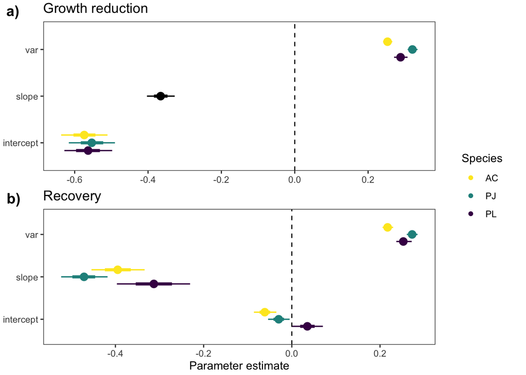

#### Main Figure

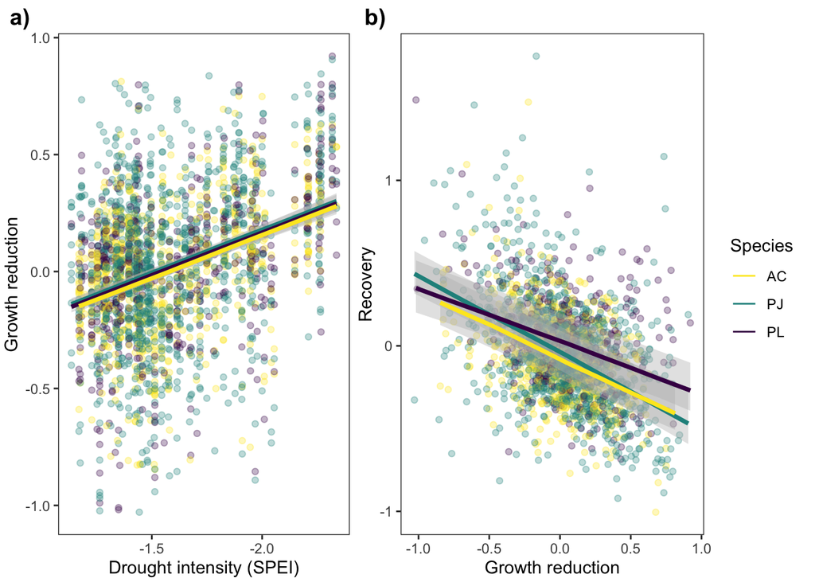

### Q2 Regional Differences

#### Growth Reduction

Table SX. A. concolor growth reduction WAIC table

|  | waic_diff | se |
| --- | --- | --- |
| Varying intercept and slope | 0.00000 | 0.00000 |
| No regional effects | 43.30953 | 12.80732 |
| Varying intercept | 45.11601 | 12.72891 |

Table SX. P. jeffreyi growth reduction WAIC table

|  | waic_diff | se |
| --- | --- | --- |
| Varying intercept and slope | 0.00000 | 0.00000 |
| Varying intercept | 41.83552 | 12.88420 |
| No regional effects | 43.82051 | 13.91644 |

Table SX. P. lambertiana growth reduction WAIC table

|  | waic_diff | se |
| --- | --- | --- |
| Varying intercept and slope | 0.00000 | 0.000000 |
| No regional effects | 18.41681 | 7.836080 |
| Varying intercept | 19.29546 | 7.449942 |

```
## # Random Effect Variances and ICC
##
## Conditioned on: ~(1 | Region)
##
## ## Variance Ratio (comparable to ICC)
## Ratio: 0.69  CI 95%: [0.48 0.81]
##
## ## Variances of Posterior Predicted Distribution
## Conditioned on fixed effects: 0.08  CI 95%: [0.06 0.15]
## Conditioned on rand. effects: 0.26  CI 95%: [0.16 0.41]
##
## ## Difference in Variances
## Difference: 0.18  CI 95%: [0.08 0.31]
```

```
## # Random Effect Variances and ICC
##
## Conditioned on: ~(1 | Region)
##
## ## Variance Ratio (comparable to ICC)
## Ratio: 0.59  CI 95%: [0.36 0.73]
##
## ## Variances of Posterior Predicted Distribution
## Conditioned on fixed effects: 0.11  CI 95%: [0.09 0.16]
## Conditioned on rand. effects: 0.27  CI 95%: [0.17 0.42]
##
## ## Difference in Variances
## Difference: 0.16  CI 95%: [0.06 0.30]
```

```
## # Random Effect Variances and ICC
##
## Conditioned on: ~(1 | Region)
##
## ## Variance Ratio (comparable to ICC)
## Ratio: 0.34  CI 95%: [-0.01 0.65]
##
## ## Variances of Posterior Predicted Distribution
## Conditioned on fixed effects: 0.11  CI 95%: [0.07 5.67]
## Conditioned on rand. effects: 0.21  CI 95%: [0.11 5.76]
##
## ## Difference in Variances
## Difference: 0.08  CI 95%: [-0.03 0.20]
```

#### Recovery

Table SX. A. concolor recovery WAIC table

|  | waic_diff | se |
| --- | --- | --- |
| Varying intercept and slope | 0.000000 | 0.000000 |
| Varying intercept | 1.851447 | 5.964911 |
| No regional effects | 12.912958 | 9.351119 |

Table SX. P. jeffreyi recovery WAIC table

|  | waic_diff | se |
| --- | --- | --- |
| Varying intercept and slope | 0.000000 | 0.000000 |
| Varying intercept | 7.988191 | 8.352711 |
| No regional effects | 22.441717 | 12.987328 |

Table SX. P. lambertiana recovery WAIC table

|  | waic_diff | se |
| --- | --- | --- |
| Varying intercept and slope | 0.000000 | 0.000000 |
| Varying intercept | 4.836886 | 8.154183 |
| No regional effects | 36.244175 | 11.872226 |

```
## # Random Effect Variances and ICC
##
## Conditioned on: ~(1 | Region)
##
## ## Variance Ratio (comparable to ICC)
## Ratio: 0.05  CI 95%: [-0.09 0.19]
##
## ## Variances of Posterior Predicted Distribution
## Conditioned on fixed effects: 0.06  CI 95%: [0.05 0.09]
## Conditioned on rand. effects: 0.06  CI 95%: [0.05 0.09]
##
## ## Difference in Variances
## Difference: 0.00  CI 95%: [-0.01 0.01]
```

```
## # Random Effect Variances and ICC
##
## Conditioned on: ~(1 | Region)
##
## ## Variance Ratio (comparable to ICC)
## Ratio: 0.03  CI 95%: [-0.09 0.14]
##
## ## Variances of Posterior Predicted Distribution
## Conditioned on fixed effects: 0.10  CI 95%: [0.08 0.17]
## Conditioned on rand. effects: 0.10  CI 95%: [0.08 0.17]
##
## ## Difference in Variances
## Difference: 0.00  CI 95%: [-0.01 0.02]
```

```
## # Random Effect Variances and ICC
##
## Conditioned on: ~(1 | Region)
##
## ## Variance Ratio (comparable to ICC)
## Ratio: 0.04  CI 95%: [-0.15 0.20]
##
## ## Variances of Posterior Predicted Distribution
## Conditioned on fixed effects: 0.08  CI 95%: [0.06 0.65]
## Conditioned on rand. effects: 0.08  CI 95%: [0.06 0.64]
##
## ## Difference in Variances
## Difference: 0.00  CI 95%: [-0.02 0.02]
```

#### Param Plots

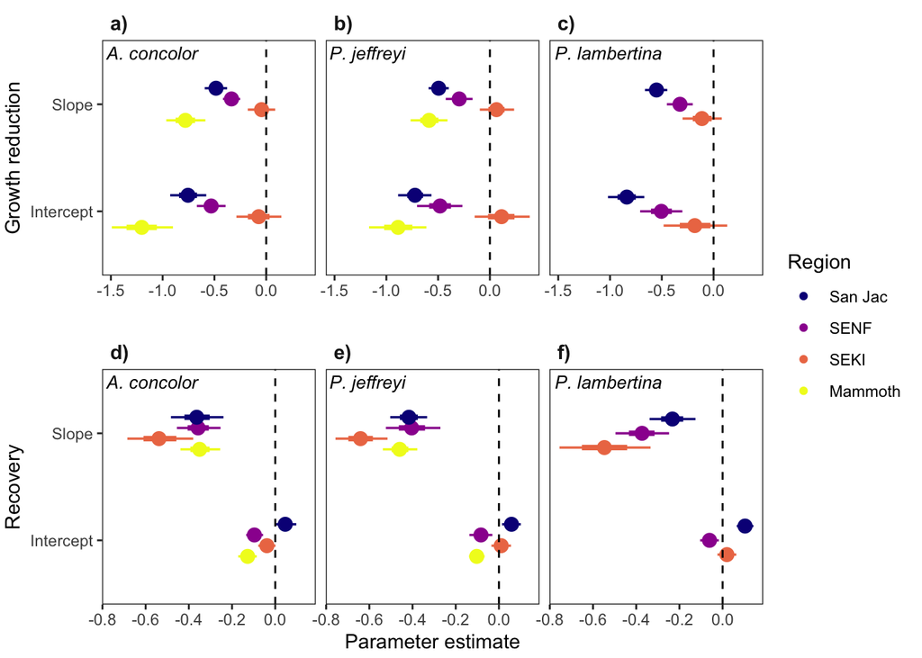

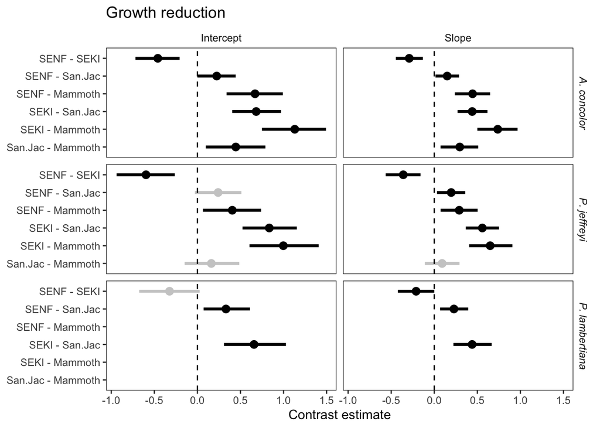

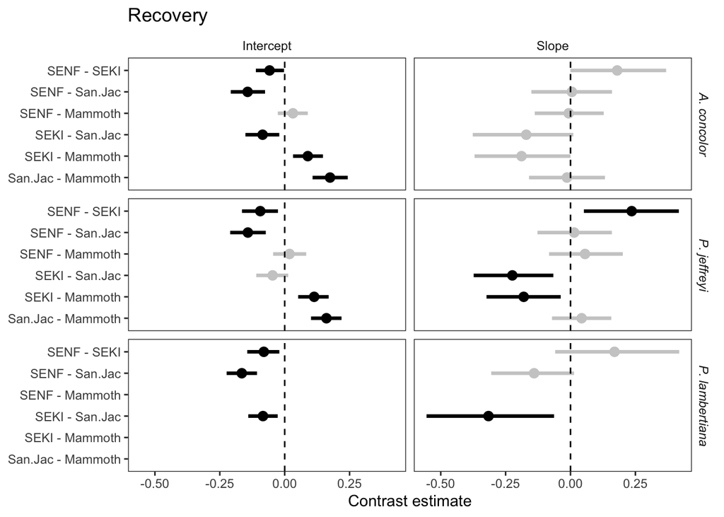

#### Main Figure

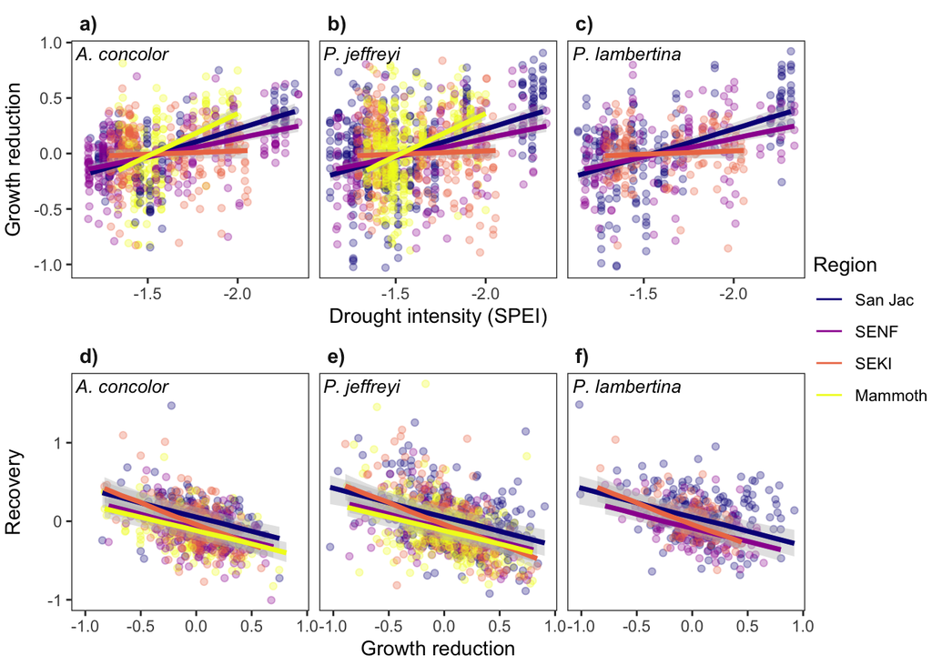

### Q3

#### Param Plots

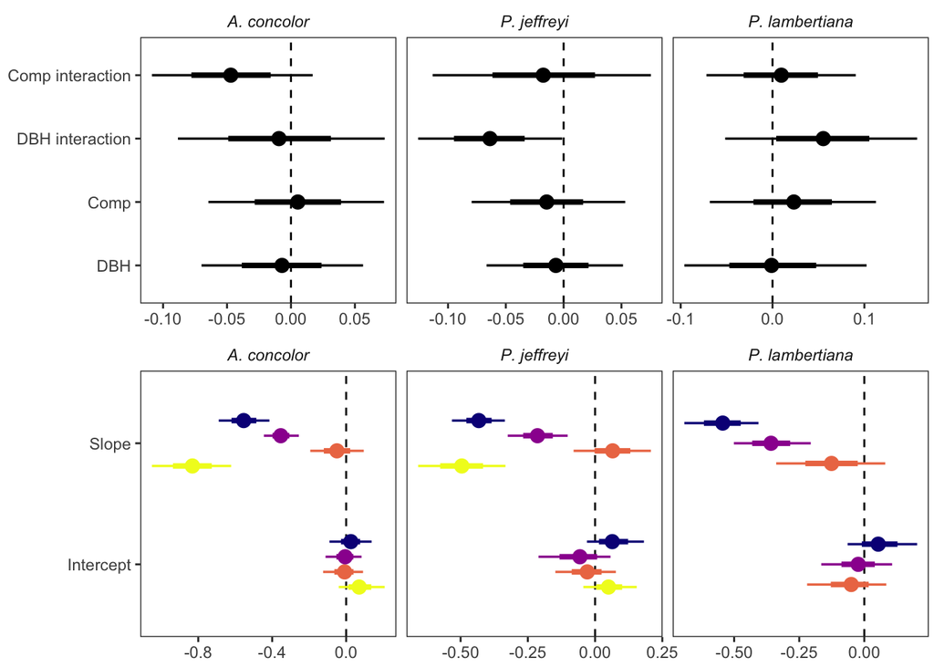

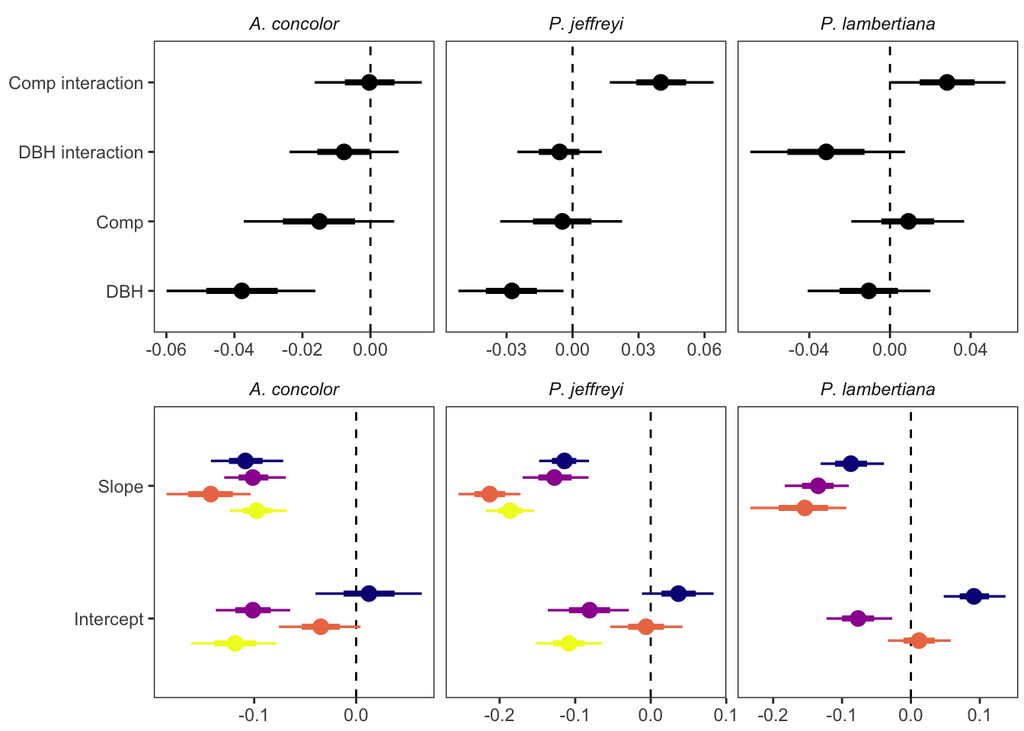

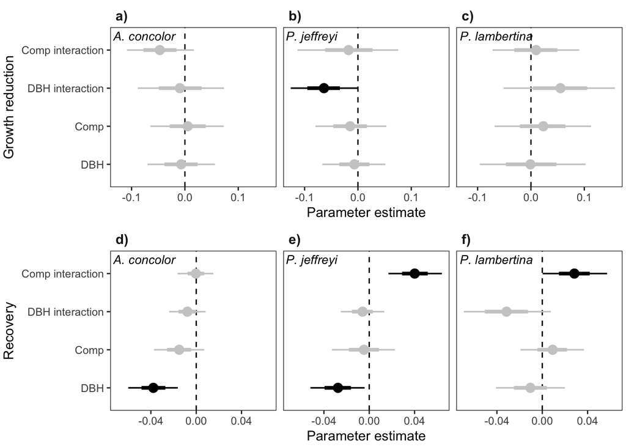

#### Main Figure

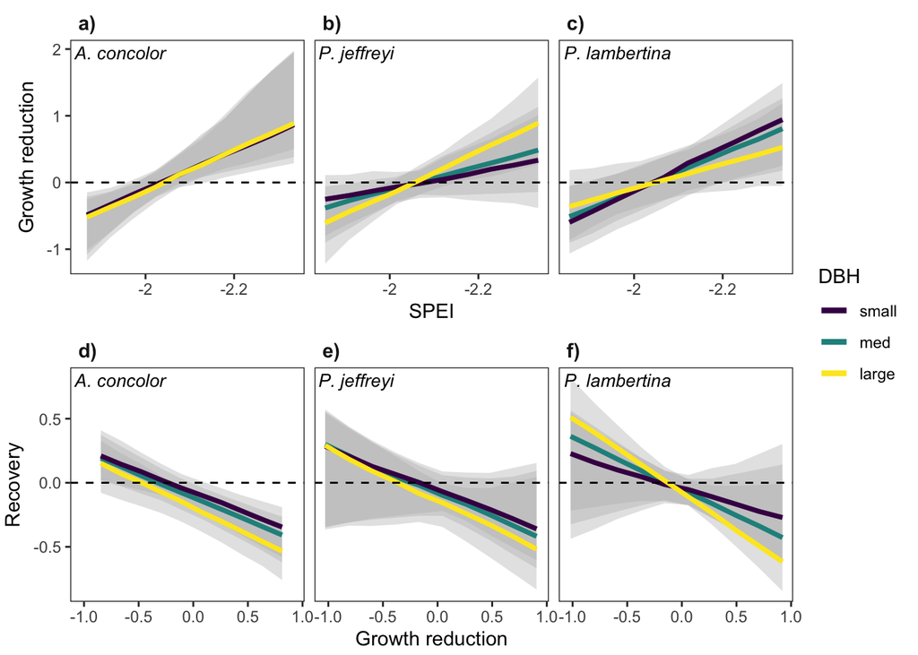

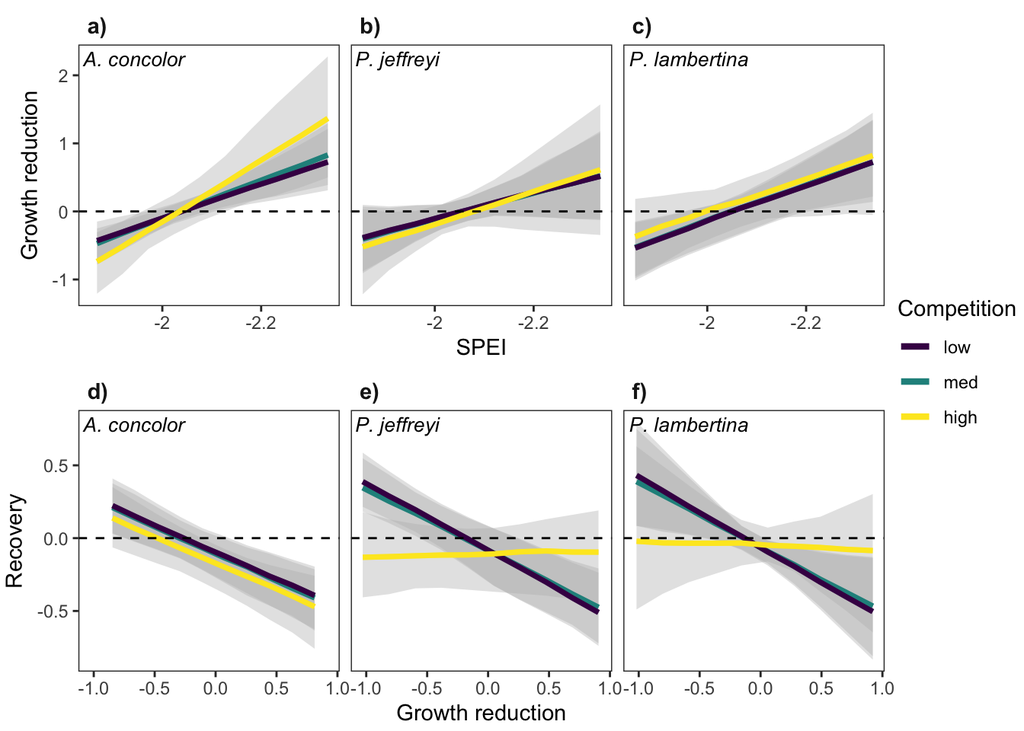

#### Growth Reduction

Keep in mind that in the scatter plots the drought intensity axis is flipped, so slope will appear to be wrong sign from the parameter estimate plots.

[figure not shown]

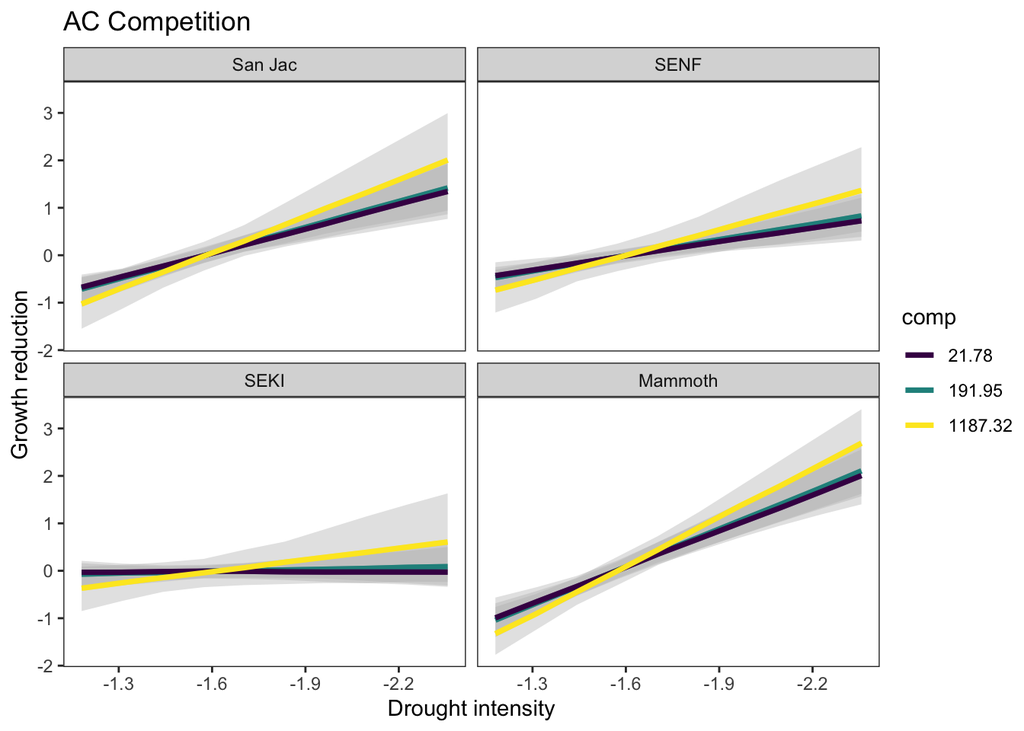

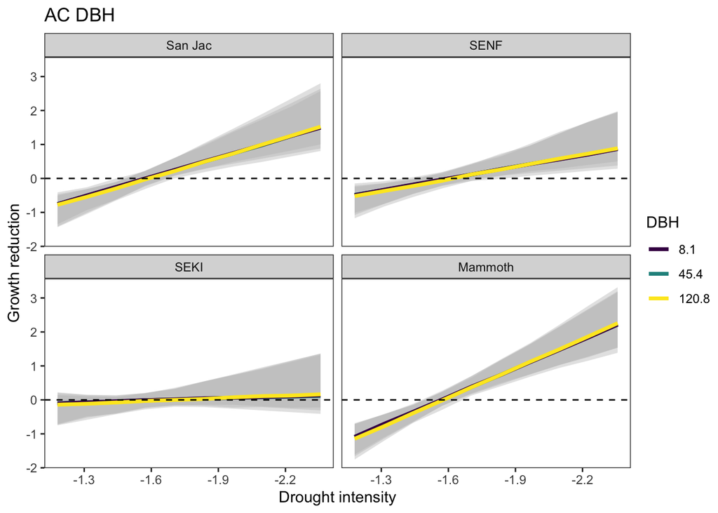

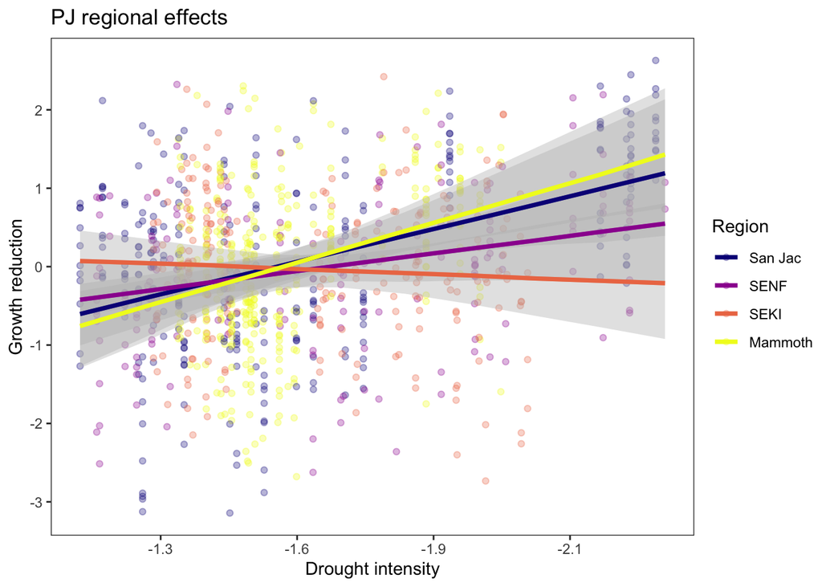

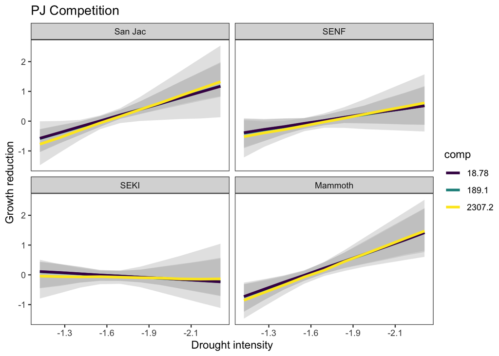

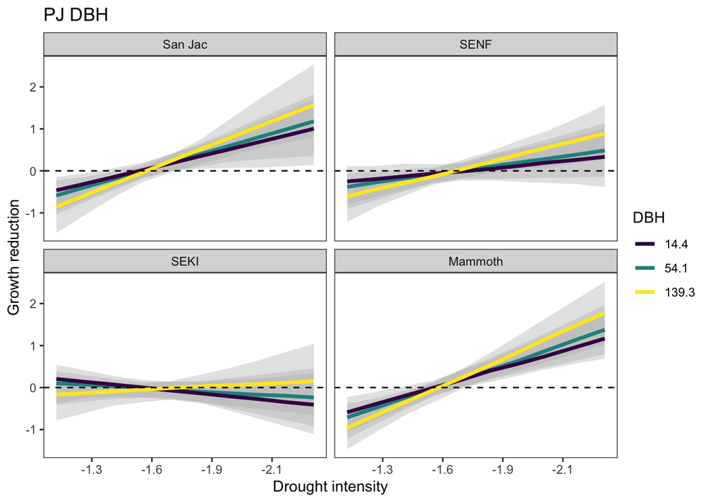

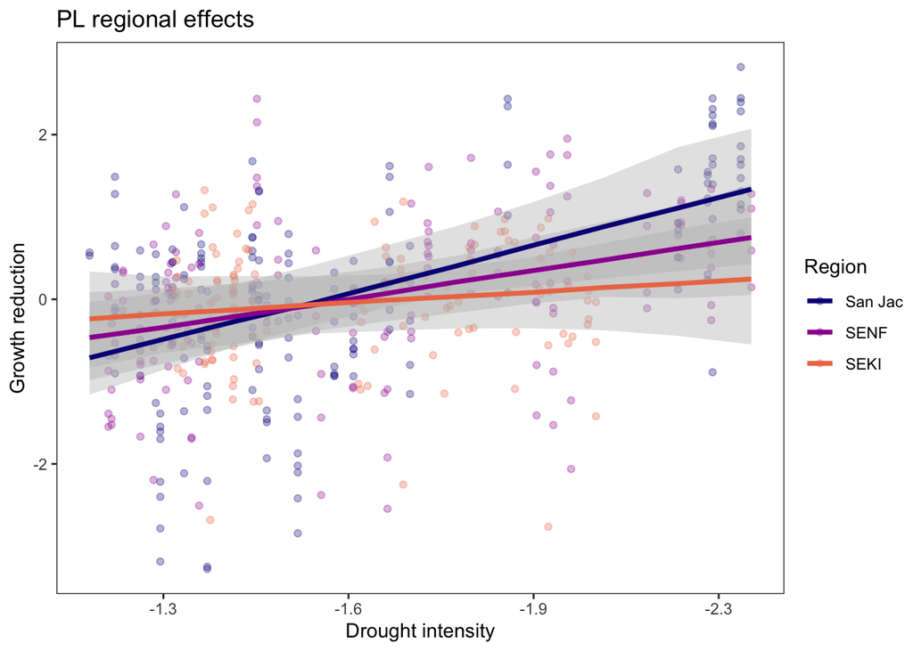

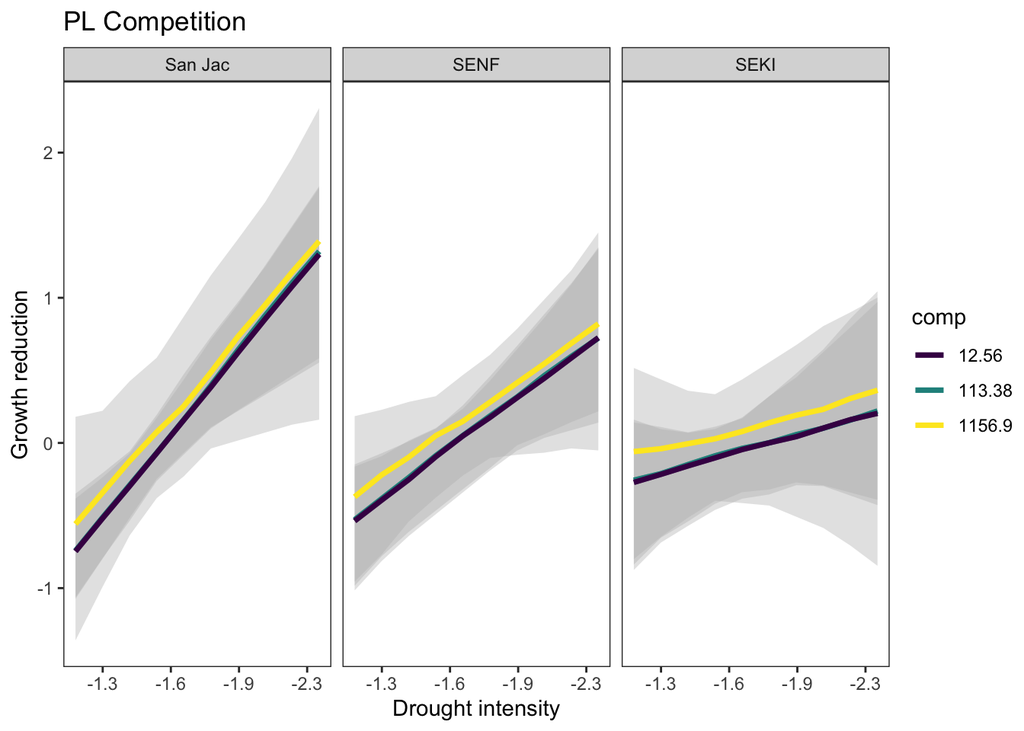

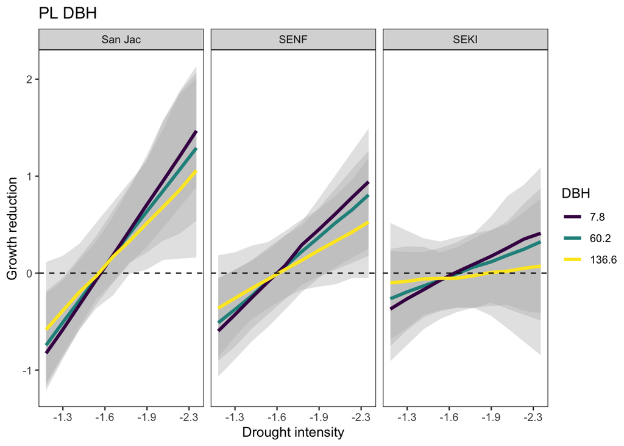

#### Recovery

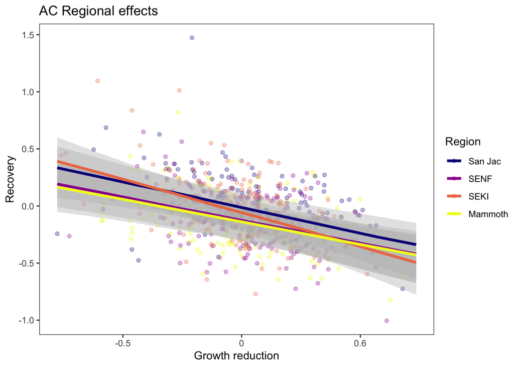

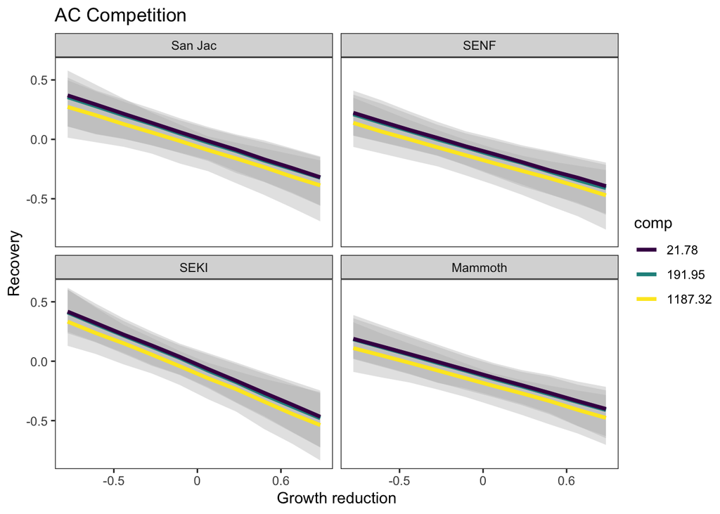

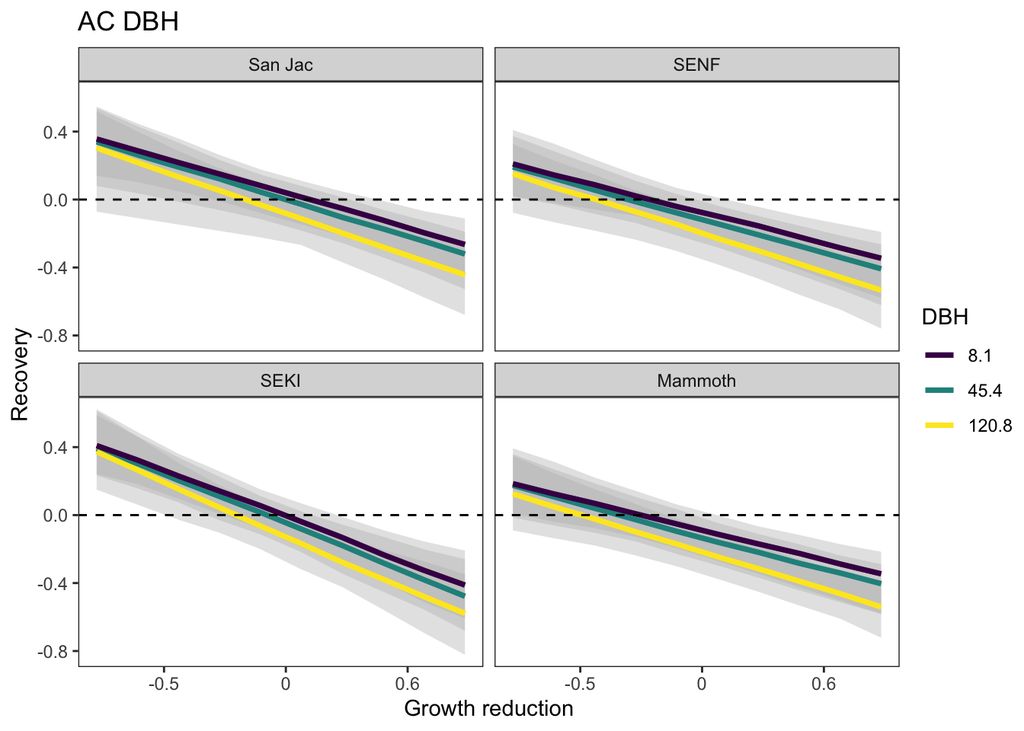

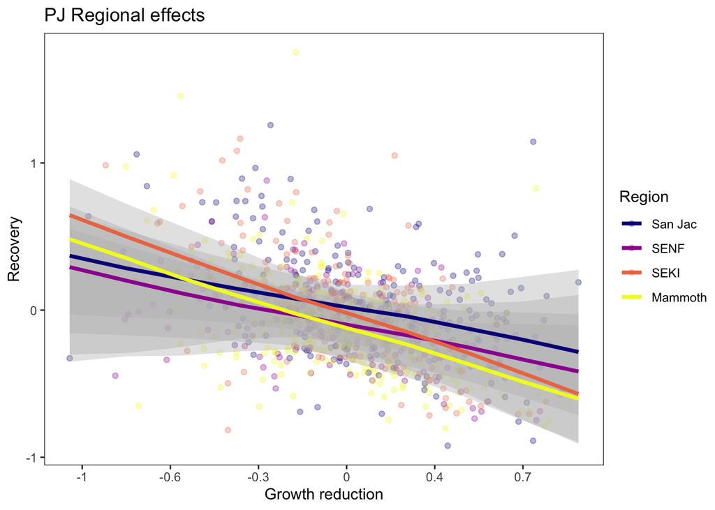